# 📈CO2 Predictions for Portugal by Miguel Caliço Jerónimo

## 📃 Introduction

The goal of this project is to develop a machine learning model that can forecast future CO2 emissions for Portugal. The model will be trained using Portuguese available data that has an impact on the CO2 emissions.

Additionally, the project will involve:

Data Collection & Preprocessing: Gathering a dataset with real data related to the topic.

Model Development: Implementing and training a model, optimizing the forecast accuracy.

Validation & Testing: Evaluating the model using real-world data.

User Interface: Designing a simple dashboard with the important information requested by the stakeholder.

## ⬇️ Imports

First we have to load all the necessary librarys

```python
import pandas as pd
import matplotlib.pyplot as plt
from sklearn.model_selection import train_test_split
from sklearn.linear_model import LinearRegression
from sklearn.neighbors import KNeighborsRegressor
from sklearn.tree import DecisionTreeRegressor
from sklearn.metrics import mean_squared_error, r2_score
```

# 📦 Data provisioning

Having the library's loaded I'm able to Load the 2 datasets I will be using for the project.

```python
# Load CO2 emissions dataset
url_co2 = 'https://github.com/owid/co2-data/raw/master/owid-co2-data.csv'
df_co2 = pd.read_csv(url_co2)

# Load Energy dataset
url_energy = 'https://github.com/owid/energy-data/raw/master/owid-energy-data.csv'
df_energy = pd.read_csv(url_energy)
```

The first datatable is C02 emissions table and consists of all the topics related to CO2 emissions. The second table is Energy and containg crucial information that can impact the CO2 emissions

After having the datasets loaded, I extract the relevant information that I will need for the development of the AI model

```python
# Extract relevant columns from the energy dataset
df_population = df_energy[['year', 'country', 'population']].dropna()
df_gdp = df_energy[['year', 'country', 'gdp']].dropna()
df_renewables = df_energy[['year', 'country', 'renewables_share_energy']].dropna()
df_fossil_fuels = df_energy[['year', 'country', 'fossil_fuel_consumption']].dropna()
```

Since I only want the data after 1965 and for Portugal which is my country of study, I procced with the code below.

```python
# Filter for global data and year above 1965
df_co2 = df_co2[(df_co2['country'] == 'Portugal') & (df_co2['year'] > 1965)][['year', 'co2']].dropna()
df_energy = df_energy[(df_energy['country'] == 'Portugal') & (df_energy['year'] > 1965)][['year', 'primary_energy_consumption']].dropna()
df_population = df_population[(df_population['country'] == 'Portugal') & (df_population['year'] > 1965)][['year', 'population']]
df_gdp = df_gdp[(df_gdp['country'] == 'Portugal') & (df_gdp['year'] > 1965)][['year', 'gdp']]
df_renewables = df_renewables[(df_renewables['country'] == 'Portugal') & (df_renewables['year'] > 1965)][['year', 'renewables_share_energy']]
df_fossil_fuels = df_fossil_fuels[(df_fossil_fuels['country'] == 'Portugal') & (df_fossil_fuels['year'] > 1965)][['year', 'fossil_fuel_consumption']]
```

Having all the dataframe loaded into the final, I merged all of them so I can get a final dataframe to work with.

```python
# Add the CSV file
df_final = pd.read_csv("C:/Users/migue/OneDrive/Ambiente de Trabalho/SEMESTER 4 - AI/Individual Challenge/df_final.csv")
```

With this line of code my goal is just simply to be able to observe the new data I added to my final dataframe

```python
# Display more rows in the output
pd.set_option('display.max_rows', 100)

# Only show the new collumns added
print(df_final[['year', 'total_GWh', 'energia_primaria', 'consumo_energia',
                'gases_estufa', 'emissoes_industria', 'produtividade_energia']])
```

```
    year  total_GWh  energia_primaria  consumo_energia  gases_estufa  \
0   1966        NaN               NaN              NaN           NaN
1   1967        NaN               NaN              NaN           NaN
2   1968        NaN               NaN              NaN           NaN
3   1969        NaN               NaN              NaN           NaN
4   1970        NaN               NaN              NaN           NaN
5   1971        NaN               NaN              NaN           NaN
6   1972        NaN               NaN              NaN           NaN
7   1973        NaN               NaN              NaN           NaN
8   1974        NaN               NaN              NaN           NaN
9   1975        NaN               NaN              NaN           NaN
10  1976        NaN               NaN              NaN           NaN
11  1977        NaN               NaN              NaN           NaN
12  1978        NaN               NaN              NaN           NaN
13  1979        NaN               NaN              NaN           NaN
```

[output cut: 108 more lines]

```python
df_final = df_final[(df_final['year'] >= 2005) & (df_final['year'] <= 2020)].reset_index(drop=True)


# Rename the features name to English for the display
print(
    df_final.rename(columns={
        'year': 'year',
        'total_GWh  ': 'total_GWh ',
        'energia_primaria': 'primary_energy_consumption ()',
        'consumo_energia': 'energy_consumption',
        'gases_estufa': 'greenhouse_gases',
        'emissoes_industria': 'industry_emissions',
        'produtividade_energia': 'energy_productivity'
    }).head()
)
```

```
   year     co2  primary_energy_consumption  population           gdp  \
0  2005  69.640                     298.263  10523314.0  2.541969e+11
1  2006  64.856                     295.874  10543946.0  2.591599e+11
2  2007  62.380                     297.491  10565547.0  2.666633e+11
3  2008  60.009                     285.505  10580963.0  2.682393e+11
4  2009  57.147                     288.234  10591341.0  2.612706e+11

   renewables_share_energy  fossil_fuel_consumption  total_GWh  \
0                    8.080                  274.163        NaN
1                   15.515                  249.968        NaN
2                   16.121                  249.533        NaN
3                   15.213                  242.072        NaN
4                   18.914                  233.716        NaN

   primary_energy_consumption ()  energy_consumption  greenhouse_gases  \
0                           24.9             27437.9               8.4
1                           24.0             26119.2               7.9
2                           23.9             26198.0               7.7
3                           23.6             25590.2               7.5
4                           23.6             25179.5               7.2

   industry_emissions  energy_productivity
0                 NaN                 6.23
1                 NaN                 6.63
2                 NaN                 6.82
3                1.07                 6.99
4                1.31                 6.89
```

# 📘 Data Dictionary

| Column Name | Description |
| --- | --- |
| `year` | Calendar year (integer). |
| `co2` | CO₂ emissions (million tonnes). |
| `primary_energy_consumption` | Total primary energy consumption (TWh). |
| `population` | Total population of Portugal. |
| `gdp` | Gross Domestic Product (constant USD). |
| `renewables_share_energy` | Share of energy from renewable sources (%). |
| `fossil_fuel_consumption` | Total fossil fuel consumption (TWh). |
| `total_GWh` | National electricity production (GWh). |
| `energia_primaria` | Primary energy production (million tonnes of oil equivalent - tep). |
| `consumo_energia` | Final energy consumption (million tonnes of oil equivalent - tep). |
| `gases_estufa` | Greenhouse gas emissions per capita (tonnes per person). |
| `emissoes_industria` | Industry CO₂ emissions per economic output (grams per euro, g/€). |
| `produtividade_energia` | Energy productivity (euros per kg of oil equivalent, €/Kg). |

# 📃 Sample the data

First we check how many null values we have

```python
print(df_final.isna().sum())
```

```
year                          0
co2                           0
primary_energy_consumption    0
population                    0
gdp                           0
renewables_share_energy       0
fossil_fuel_consumption       0
total_GWh                     5
energia_primaria              0
consumo_energia               0
gases_estufa                  0
emissoes_industria            3
produtividade_energia         0
dtype: int64
```

In this case "total_Gwh" as a couple of null values, as well as "emissoes_industria".

Folowing the previous step, we check how many duplicates we have in the dataset

```python
print(df_final.duplicated().sum())  # Total duplicates
```

```
0
```

We have 0 duplicates which is a good sign and was already expected having in count the databset.

After all the data is cleaned and simplified we can summarise the data having an overview of basic statics such as the mean, count, min, max, etc

```python
print(df_final.describe())
```

```
              year        co2  primary_energy_consumption    population  \
count    16.000000  16.000000                   16.000000  1.600000e+01
mean   2012.500000  53.943500                  292.030250  1.045231e+07
std       4.760952   7.252612                   12.759317  1.209948e+05
min    2005.000000  41.738000                  264.467000  1.028983e+07
25%    2008.750000  49.485500                  289.200000  1.032645e+07
50%    2012.500000  52.008500                  292.415500  1.049331e+07
75%    2016.250000  57.862500                  299.166750  1.056500e+07
max    2020.000000  69.640000                  309.867000  1.059134e+07

                gdp  renewables_share_energy  fossil_fuel_consumption  \
count  1.600000e+01                16.000000                 16.00000
mean   2.633948e+11                23.024375                224.85575
std    9.813182e+09                 6.725416                 22.52155
min    2.504052e+11                 8.080000                181.05900
25%    2.562332e+11                18.215750                213.54125
50%    2.624122e+11                24.610000                219.65100
75%    2.675179e+11                27.941250                238.38050
max    2.865056e+11                31.740000                274.16300

          total_GWh  energia_primaria  consumo_energia  gases_estufa  \
count     11.000000         16.000000          16.0000     16.000000
mean   49789.454545         22.375000       24202.9000      6.956250
std     1079.198162          1.428052        1614.2162      0.672278
min    48815.000000         19.500000       21400.1000      5.700000
25%    49012.000000         21.525000       23319.7000      6.575000
50%    49275.000000         22.400000       23970.1500      6.800000
75%    50424.500000         23.600000       25282.1750      7.275000
max    52198.000000         24.900000       27437.9000      8.400000

       emissoes_industria  produtividade_energia
count           13.000000              16.000000
mean             1.688462               7.164375
std              0.455501               0.411144
min              0.800000               6.230000
25%              1.310000               6.965000
50%              1.820000               7.230000
75%              1.920000               7.315000
max              2.480000               7.960000
```

We also got a quick overview of the data types, null counts, etc, where we can once more check the integrity of the data

```python
print(df_final.info())
```

```
<class 'pandas.core.frame.DataFrame'>
RangeIndex: 16 entries, 0 to 15
Data columns (total 13 columns):
 #   Column                      Non-Null Count  Dtype
---  ------                      --------------  -----
 0   year                        16 non-null     int64
 1   co2                         16 non-null     float64
 2   primary_energy_consumption  16 non-null     float64
 3   population                  16 non-null     float64
 4   gdp                         16 non-null     float64
 5   renewables_share_energy     16 non-null     float64
 6   fossil_fuel_consumption     16 non-null     float64
 7   total_GWh                   11 non-null     float64
 8   energia_primaria            16 non-null     float64
 9   consumo_energia             16 non-null     float64
 10  gases_estufa                16 non-null     float64
 11  emissoes_industria          13 non-null     float64
 12  produtividade_energia       16 non-null     float64
dtypes: float64(12), int64(1)
memory usage: 1.8 KB
None
```

After all data is collected and cleaned it is possible to create some graphs to help visualize the data, therefore we created some graphs where is possible to check the distribution of the CO2 emissions, and the influence all the factors have on them.

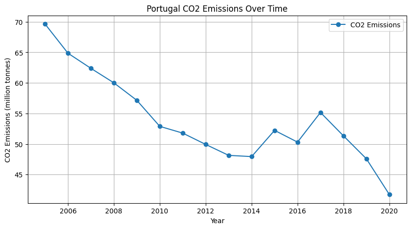

```python
import matplotlib.pyplot as plt

# Visualize historical CO2 emissions
plt.figure(figsize=(10, 5))
plt.plot(df_final['year'], df_final['co2'], marker='o', linestyle='-', label='CO2 Emissions')


plt.xlabel('Year')
plt.ylabel('CO2 Emissions (million tonnes)')
plt.title('Portugal CO2 Emissions Over Time')
plt.legend()
plt.grid()
plt.show()
```

As It's possible to see the CO2 emissions in Portugal have been decreasion in the last 20 years, which is concordant to the information in the domain understanding

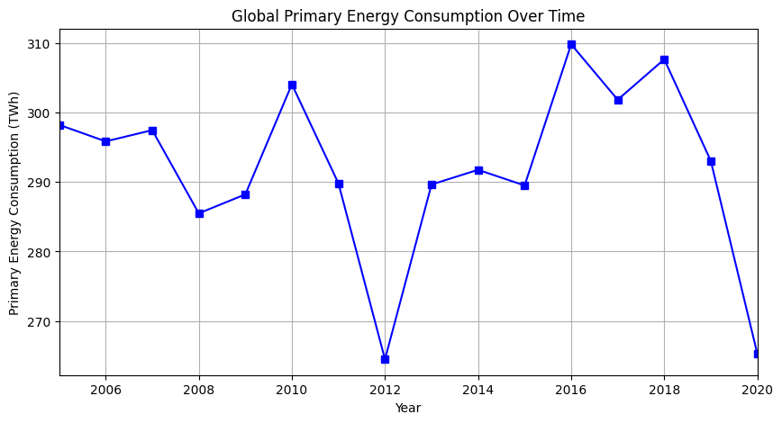

```python
import matplotlib.pyplot as plt

plt.figure(figsize=(10,5))
plt.plot(df_final['year'], df_final['primary_energy_consumption'], marker='s', linestyle='-', color='blue')
plt.xlabel('Year')
plt.ylabel('Primary Energy Consumption (TWh)')
plt.title('Global Primary Energy Consumption Over Time')
plt.grid(True)

# Limitar visualização do eixo X
plt.xlim(2005, 2020)

plt.show()
```

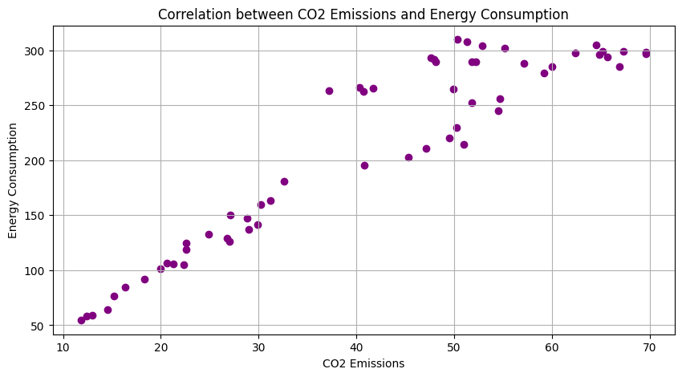

```python
import matplotlib.pyplot as plt

# Create a scatter plot to show the correlation
fig, ax = plt.subplots(figsize=(10,5))

# Plot CO2 emissions vs. Energy consumption as a scatter plot
ax.scatter(df_co2['co2'], df_energy['primary_energy_consumption'], color='purple', marker='o')

# Label the axes
ax.set_xlabel('CO2 Emissions')
ax.set_ylabel('Energy Consumption')

# Title of the plot
plt.title('Correlation between CO2 Emissions and Energy Consumption')

# Grid for better visibility
plt.grid(True)

# Show the plot
plt.show()
```

The scatter plot above reveals a clear positive relationship between Portugal’s CO₂ emissions and its primary energy consumption, indicating that years with higher energy use correspond to higher emissions.

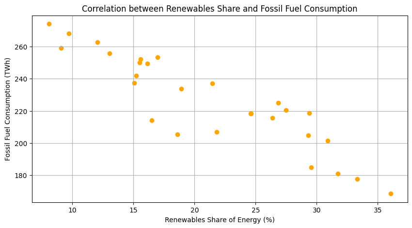

```python
import matplotlib.pyplot as plt

# Create a scatter plot to show the correlation
fig, ax = plt.subplots(figsize=(10,5))

# Plot Renewables Share vs. Fossil Fuel Consumption as a scatter plot
ax.scatter(df_renewables['renewables_share_energy'], df_fossil_fuels['fossil_fuel_consumption'], color='orange', marker='o')

# Label the axes
ax.set_xlabel('Renewables Share of Energy (%)')
ax.set_ylabel('Fossil Fuel Consumption (TWh)')

# Title of the plot
plt.title('Correlation between Renewables Share and Fossil Fuel Consumption')

# Grid for better visibility
plt.grid(True)

# Show the plot
plt.show()
```

The scatter plot above illustrates that as Portugal’s share of renewable energy grows, its fossil fuel consumption tends to decline, suggesting a gradual shift toward cleaner energy sources.

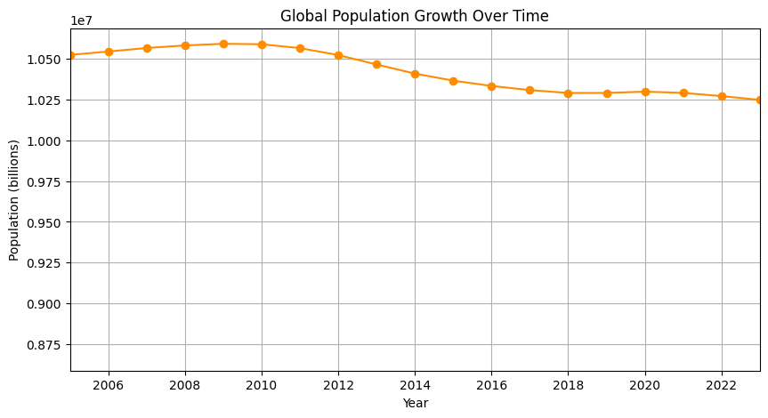

```python
plt.figure(figsize=(10,5))
plt.plot(df_population['year'], df_population['population'], marker='o', linestyle='-', color='darkorange')
plt.xlabel('Year')
plt.ylabel('Population (billions)')
plt.title('Global Population Growth Over Time')
plt.grid(True)
# Limitar visualização do eixo X
plt.xlim(2005, 2023)
plt.show()
```

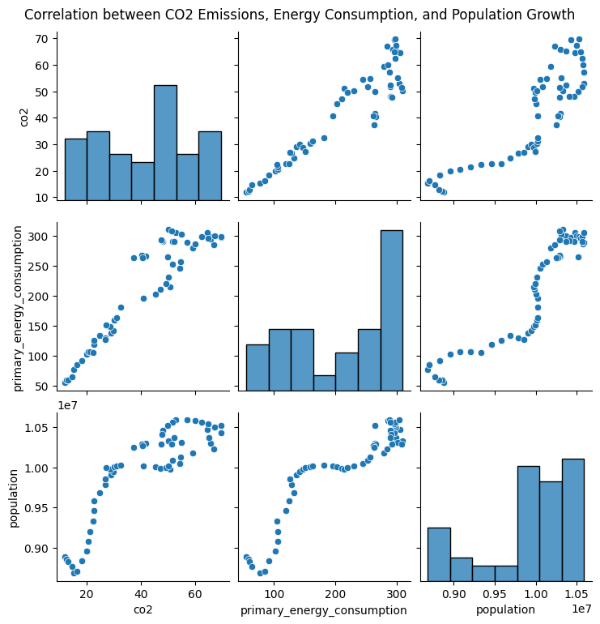

```
Correlation Matrix:
                                 co2  primary_energy_consumption  population
co2                         1.000000                    0.936359    0.863904
primary_energy_consumption  0.936359                    1.000000    0.920540
population                  0.863904                    0.920540    1.000000
```

```python
import seaborn as sns
import matplotlib.pyplot as plt
import pandas as pd


# Merge the three datasets on 'year' for easier correlation plotting
df_merged = pd.merge(df_co2, df_energy, on='year')
df_merged = pd.merge(df_merged, df_population, on='year')

# Create a correlation matrix for all three variables
corr_matrix = df_merged[['co2', 'primary_energy_consumption', 'population']].corr()

# Plot the pair plot (scatter plot matrix) to show correlations
sns.pairplot(df_merged[['co2', 'primary_energy_consumption', 'population']])
plt.suptitle('Correlation between CO2 Emissions, Energy Consumption, and Population Growth', y=1.02)
plt.show()

# Optionally, you can print the correlation matrix for a numerical summary
print("Correlation Matrix:")
print(corr_matrix)
```

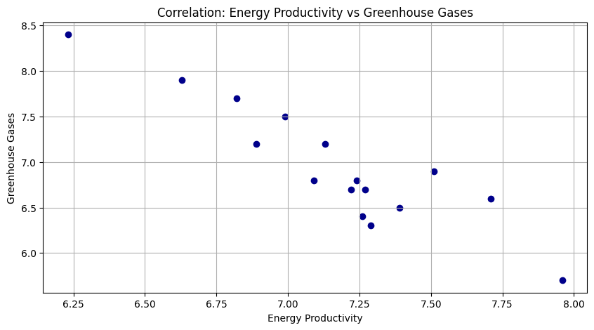

```python
fig, ax = plt.subplots(figsize=(10, 5))
ax.scatter(df_final['produtividade_energia'], df_final['gases_estufa'], color='darkblue', marker='o')
ax.set_title('Correlation: Energy Productivity vs Greenhouse Gases')
ax.set_xlabel('Energy Productivity')
ax.set_ylabel('Greenhouse Gases')
ax.grid(True)
plt.show()
```

As it's possible to see, there is a linear relation between Energy Productivity and Greenhouse Gases.

# 🛠️ Preprocessing

```python
from sklearn import preprocessing

# Example: Encoding a categorical feature (if applicable)
if 'country' in df_final.columns:
    encoder = preprocessing.LabelEncoder()
    df_final["country_id"] = encoder.fit_transform(df_final["country"])
    df_final = df_final.drop(["country"], axis=1)  # Drop original categorical column

df_final.sample(10)  # View a random sample of 10 rows
```

|  | year | co2 | primary_energy_consumption | population | gdp | renewables_share_energy | fossil_fuel_consumption | total_GWh | energia_primaria | consumo_energia | gases_estufa | emissoes_industria | produtividade_energia |
| --- | --- | --- | --- | --- | --- | --- | --- | --- | --- | --- | --- | --- | --- |
| 5 | 2010 | 52.890 | 304.105 | 10588401.0 | 2.672774e+11 | 27.482 | 220.531 | 52198.0 | 22.7 | 24383.4 | 6.8 | 0.80 | 7.24 |
| 8 | 2013 | 48.146 | 289.661 | 10464537.0 | 2.504052e+11 | 29.319 | 204.735 | 49154.0 | 21.0 | 22396.8 | 6.3 | 1.78 | 7.29 |
| 7 | 2012 | 49.932 | 264.467 | 10522085.0 | 2.527371e+11 | 21.804 | 206.804 | 49061.0 | 21.0 | 22362.6 | 6.5 | 1.88 | 7.39 |
| 10 | 2015 | 52.233 | 289.522 | 10365436.0 | 2.569119e+11 | 24.607 | 218.280 | 48963.0 | 21.7 | 23588.9 | 6.8 | 1.92 | 7.09 |
| 14 | 2019 | 47.583 | 293.057 | 10289921.0 | 2.865056e+11 | 26.367 | 215.787 | 50348.0 | 22.1 | 23905.6 | 6.6 | 1.89 | 7.71 |
| 2 | 2007 | 62.380 | 297.491 | 10565547.0 | 2.666633e+11 | 16.121 | 249.533 | NaN | 23.9 | 26198.0 | 7.7 | NaN | 6.82 |
| 6 | 2011 | 51.784 | 289.831 | 10564820.0 | 2.634250e+11 | 24.613 | 218.494 | 50501.0 | 22.0 | 23769.8 | 6.7 | 1.24 | 7.27 |
| 11 | 2016 | 50.311 | 309.867 | 10332751.0 | 2.621001e+11 | 29.398 | 218.771 | 49275.0 | 21.8 | 23521.1 | 6.7 | 2.00 | 7.22 |
| 15 | 2020 | 41.738 | 265.248 | 10298186.0 | 2.627242e+11 | 31.740 | 181.059 | 48815.0 | 19.5 | 21400.1 | 5.7 | 2.48 | 7.96 |
| 1 | 2006 | 64.856 | 295.874 | 10543946.0 | 2.591599e+11 | 15.515 | 249.968 | NaN | 24.0 | 26119.2 | 7.9 | NaN | 6.63 |

# 💡 Feature selection

To be able to choose the right features, an heatmap is crucial to understand how are the features related to the target which is CO2

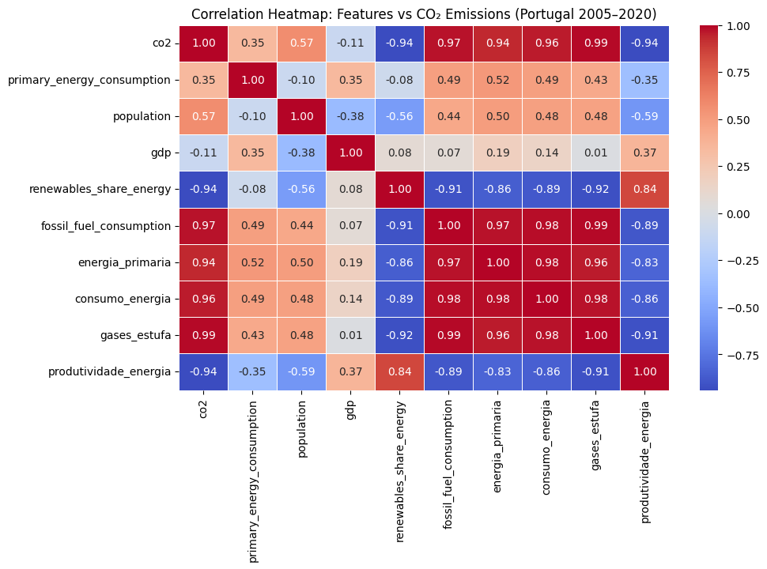

```python
import seaborn as sns
import matplotlib.pyplot as plt

# Select only relevant features including CO2
features_of_interest = df_final[['co2', 'primary_energy_consumption', 'population', 'gdp', 'renewables_share_energy', 'fossil_fuel_consumption', 'energia_primaria', 'consumo_energia', 'gases_estufa', 'produtividade_energia']]

# Compute correlation matrix
corr_matrix = features_of_interest.corr()

# Plot the heatmap
plt.figure(figsize=(10, 6))
sns.heatmap(corr_matrix, annot=True, cmap='coolwarm', fmt=".2f", linewidths=0.5)
plt.title('Correlation Heatmap: Features vs CO₂ Emissions (Portugal 2005–2020)')
plt.show()
```

From the heatmap, we can conclude that the features most strongly correlated with CO₂ emissions in Portugal between 2005 and 2020 are gases_estufa (0.99), fossil_fuel_consumption (0.97), consumo_energia (0.96), and energia_primaria (0.94). These very high positive correlations indicate that as these variables increase, CO₂ emissions also tend to increase proportionally, making them excellent candidates for predicting future emissions. On the other hand, renewables_share_energy (-0.94) and produtividade_energia (-0.94) are strongly negatively correlated with CO₂, meaning that higher renewable energy usage and better energy productivity are linked to lower emissions. These features are also valuable for prediction, especially in scenarios focusing on mitigation. Variables like population (0.57) and primary_energy_consumption (0.35) show only moderate or weak correlations, and GDP (-0.11) appears almost unrelated, suggesting limited predictive power for CO₂ in this context.

```python
features = ['year', 'renewables_share_energy', 'fossil_fuel_consumption', 'energia_primaria', 'consumo_energia', 'gases_estufa', 'produtividade_energia']
X = df_final[features]
y = df_final['co2']
```

# Splitting into train/test

In the code below, I divide the observations I have into test and train so I can train the model.

```python
from sklearn.model_selection import train_test_split
X_train, X_test, y_train, y_test = train_test_split(X, y, test_size=0.3, random_state=42)
print("There are in total", len(X), "observations, of which", len(X_train), "are now in the train set, and", len(X_test), " in the test set.")
```

```
There are in total 16 observations, of which 11 are now in the train set, and 5  in the test set.
```

# Scaling

The code below standardizes the features so they all have mean 0 and standard deviation 1, which helps linear regression perform better when features have different scales.

```python
from sklearn.preprocessing import StandardScaler

scaler = StandardScaler()
scaler.fit(X_train)
X_train = scaler.transform(X_train)
X_test = scaler.transform(X_test)
```

# 🧬 Modelling

The code below trains three different models (Linear Regression, KNN, and Decision Tree), evaluates each on the test set, and prints their Mean Squared Error and R² score to compare performance.

```python
# Initialize models
models = {
    'Linear Regression': LinearRegression(),
    'K-Nearest Neighbors': KNeighborsRegressor(),
    'Decision Tree': DecisionTreeRegressor()
}

# Train and evaluate models
for name, model in models.items():
    model.fit(X_train, y_train)
    y_pred = model.predict(X_test)
    mse = mean_squared_error(y_test, y_pred)
    r2 = r2_score(y_test, y_pred)
    print(f'{name} - MSE: {mse:.2f}, R²: {r2:.2f}')
```

```
Linear Regression - MSE: 2.32, R²: 0.97
K-Nearest Neighbors - MSE: 43.72, R²: 0.39
Decision Tree - MSE: 25.67, R²: 0.64
```

As it's possible to notice the Linear Regression is the most suitable one for this problem.

This code uses linear regression to predict CO₂ emissions in Portugal for the next 10 years by first forecasting all relevant features based on the year, then feeding those predictions into a model trained on past data to predict future CO₂ levels.

```python
from sklearn.linear_model import LinearRegression

# Define features again
features = ['year', 'primary_energy_consumption', 'population', 'gdp', 'renewables_share_energy',
            'fossil_fuel_consumption', 'energia_primaria', 'consumo_energia', 'gases_estufa', 'produtividade_energia']

X = df_final[features]
y = df_final['co2']

# Train best model (e.g., Linear Regression)
best_model = LinearRegression()
best_model.fit(X, y)

# Create DataFrame for future years
future_years = pd.DataFrame({'year': range(df_final['year'].max() + 1, df_final['year'].max() + 11)})

# Predict each feature using linear regression on 'year'
for feature in features:
    if feature != 'year':  # Don't predict 'year' itself
        trend_model = LinearRegression().fit(df_final[['year']], df_final[feature])
        future_years[feature] = trend_model.predict(future_years[['year']])

# Prepare full future feature set
X_future = future_years[features]

# Predict CO2
future_years['predicted_co2_emissions'] = best_model.predict(X_future)

print(future_years)
```

```
   year  primary_energy_consumption    population           gdp  \
0  2021                  289.998075  1.025700e+07  2.704614e+11
1  2022                  289.758996  1.023402e+07  2.712927e+11
2  2023                  289.519916  1.021105e+07  2.721241e+11
3  2024                  289.280837  1.018807e+07  2.729555e+11
4  2025                  289.041757  1.016509e+07  2.737868e+11
5  2026                  288.802678  1.014211e+07  2.746182e+11
6  2027                  288.563599  1.011914e+07  2.754496e+11
7  2028                  288.324519  1.009616e+07  2.762809e+11
8  2029                  288.085440  1.007318e+07  2.771123e+11
9  2030                  287.846360  1.005020e+07  2.779437e+11

   renewables_share_energy  fossil_fuel_consumption  energia_primaria  \
0                32.470275               195.813650         20.530000
1                33.581557               192.396932         20.312941
```

[output cut: 32 more lines]

# 🔬 Evaluation

```python
import plotly.graph_objects as go

fig = go.Figure()

# Historical data
fig.add_trace(go.Scatter(
    x=df_final['year'],
    y=df_final['co2'],
    mode='lines+markers',
    name='Historical CO2 Data'
))

# Predicted data
fig.add_trace(go.Scatter(
    x=future_years['year'],
    y=future_years['predicted_co2_emissions'],
    mode='lines+markers',
    name='Predicted CO2 Data',
    line=dict(dash='dash', color='red')
))

# Layout
fig.update_layout(
    title='CO2 Emissions Prediction',
    xaxis_title='Year',
    yaxis_title='CO2 Emissions (million tonnes)',
    legend=dict(x=0.05, y=0.95),
    template='plotly_white'
)

fig.show()
```

[output not shown]

```python
# Filter the DataFrame for years 2020 and above
df_co2_filtered = df_co2[df_co2['year'] >= 2020]

# Print the filtered DataFrame
print(df_co2_filtered)
```

```
       year     co2
37628  2020  41.738
37629  2021  40.284
37630  2022  40.687
37631  2023  37.228
```